| title: “LABOTARIO_BONUS” |
| --- |
| author: “JESSICA PAOLA AGUILAR SERVIN” |
| date: “2023-03-11” |
| output: html_document |

LABORATORIO PLOT HOOVER CURVE ##############################

INSTALAR PREVIAMENTE install.packages(“devtools”) install.packages(“devtools”, type = “win.binary”)

```r
library(devtools)
library(EconGeo)
```

generate vectors industrial

```r
ind <- c(0, 10, 10, 30, 50)
pop <- c(10, 15, 20, 25, 30)
```

CHECK VECTOR

```r
ind
```

```
## [1]  0 10 10 30 50
```

CHECK VECTOR POP

```r
pop
```

```
## [1] 10 15 20 25 30
```

RUN THE FUNTION (30% de la poblacion produce 50% de los resultados industriales)

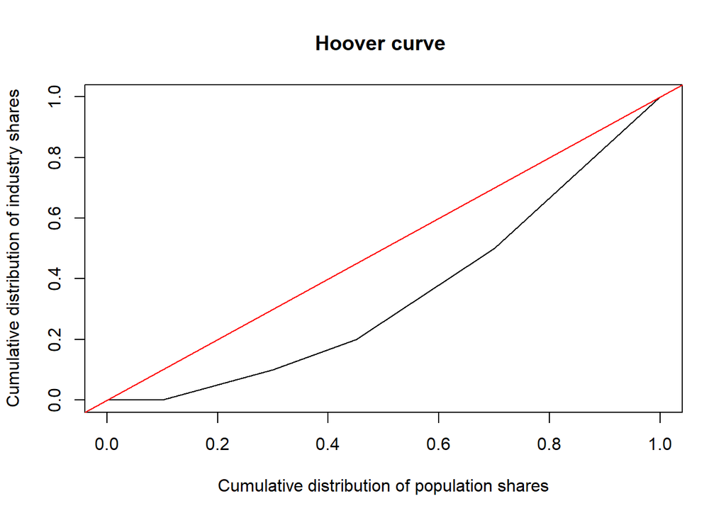

```r
Hoover.curve (ind, pop)
```

COMPUTE HOOVER GINI

```r
Hoover.Gini (ind, pop)
```

```
## [1] 0.31
```

[output not shown]

LABORATORIO LOCATIONAL GINI ##############################

GENERATE REGION- INDUSTRI MATRIX

```r
mat = matrix (
  c (100, 0, 0, 0, 0,
     0, 15, 5, 70, 10,
     0, 20, 10, 20, 50,
     0, 25, 30, 5, 40,
     0, 40, 55, 5, 0), ncol = 5, byrow = T)
rownames(mat) <- c ("R1", "R2", "R3", "R4", "R5")
colnames(mat) <- c ("I1", "I2", "I3", "I4", "I5")
```

RUN THE FUNCTION

```r
locational.Gini (mat)
```

```
##   Industry Loc.Gini
## 1       I1     0.40
## 2       I2     0.18
## 3       I3     0.27
## 4       I4     0.31
## 5       I5     0.28
```

############################## LOCATIONAL.GINI_CURVE ##############################

GENERATE A RECION-INDUSTRI MATRIX

`r mat = matrix ( c (100, 0, 0, 0, 0, 0, 15, 5, 70, 10, 0, 20, 10, 20, 50, 0, 25, 30, 5, 40, 0, 40, 55, 5, 0), ncol = 5, byrow = T) rownames(mat) <- c ("R1", "R2", "R3", "R4", "R5") colnames(mat) <- c ("I1", "I2", "I3", "I4", "I5")`

`r locational.Gini.curve (mat)`

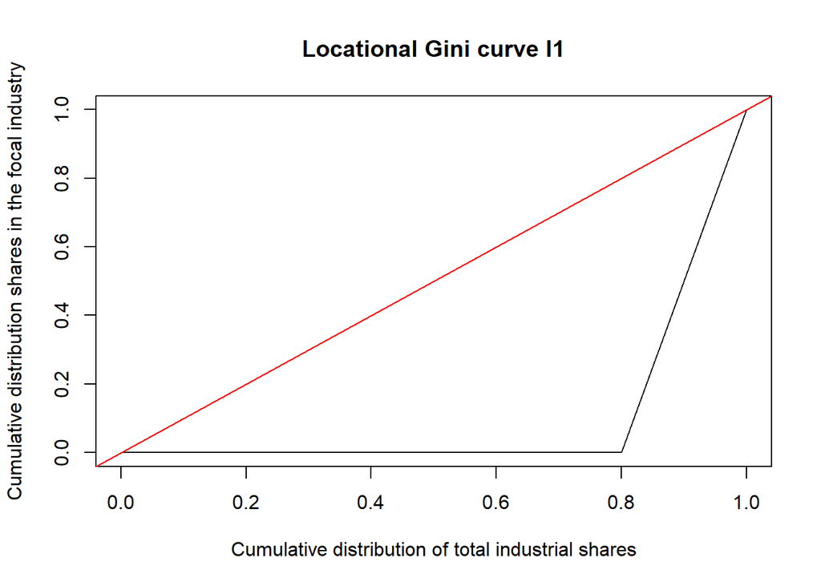

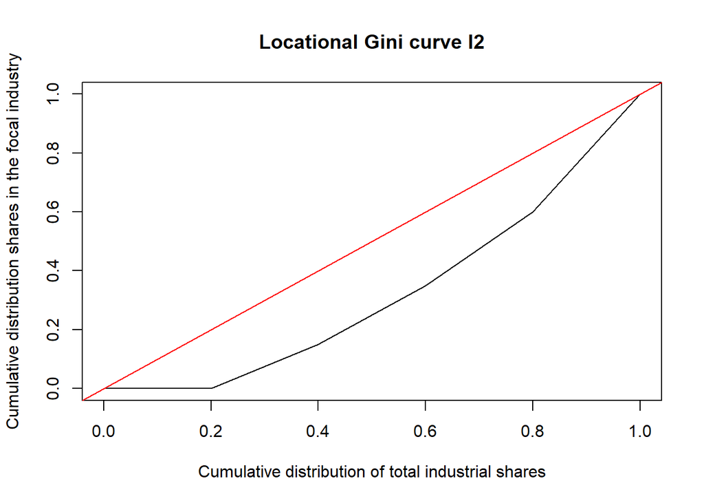

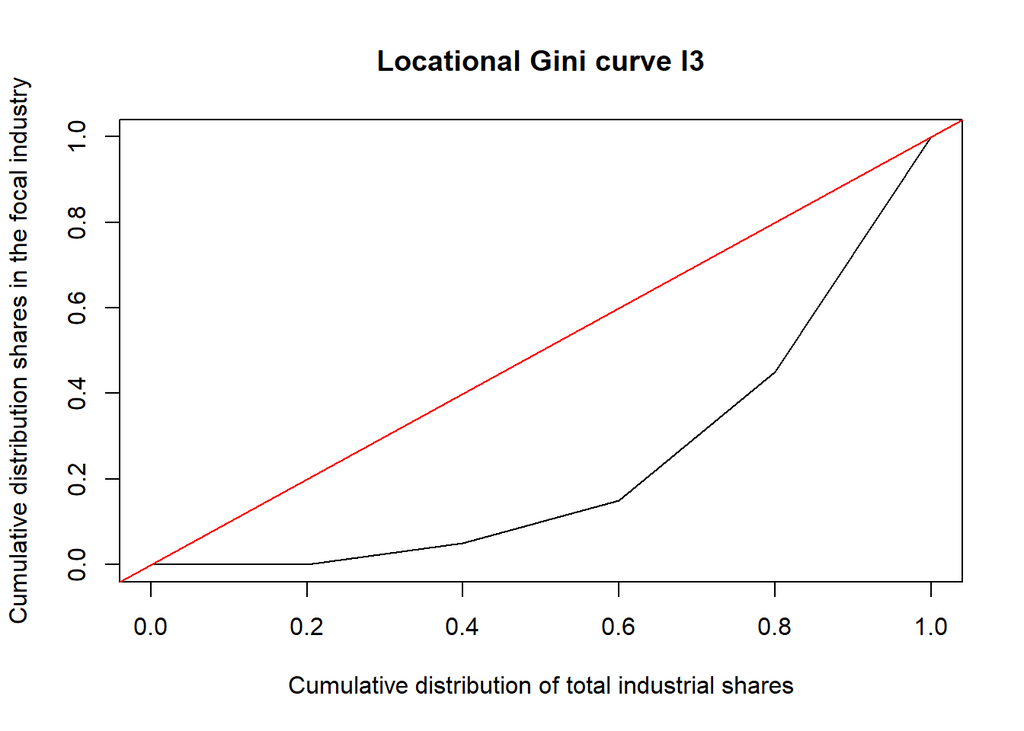

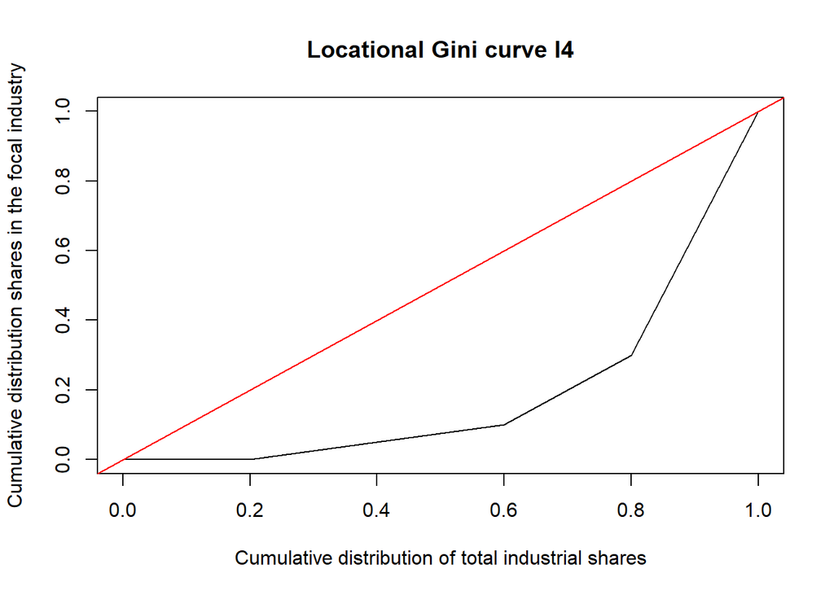

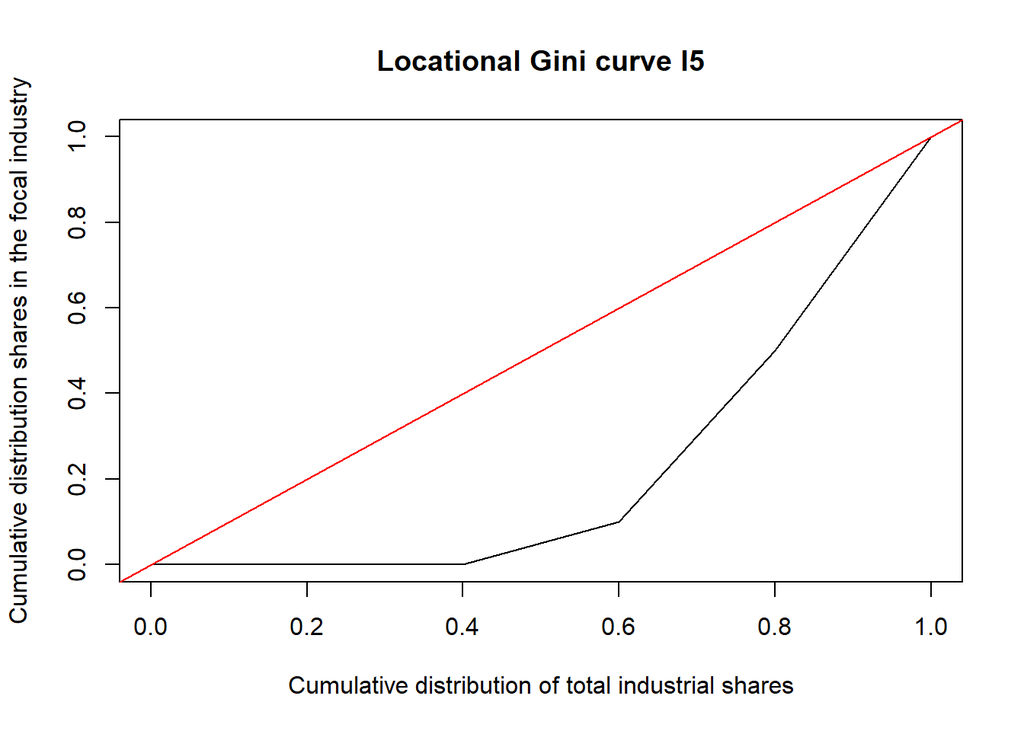

`r locational.Gini.curve (mat, pdf = TRUE)`

`## [1] "locational.Gini.curve.pdf has been saved to your current working directory"`

LABORATORIO LORENZ.CURVE  
#################################

GENERATE VECTORS OF INDUSTRIAL COUNT

```r
ind <- c(0, 10, 10, 30, 50)
```

RUN THE FUNCTION

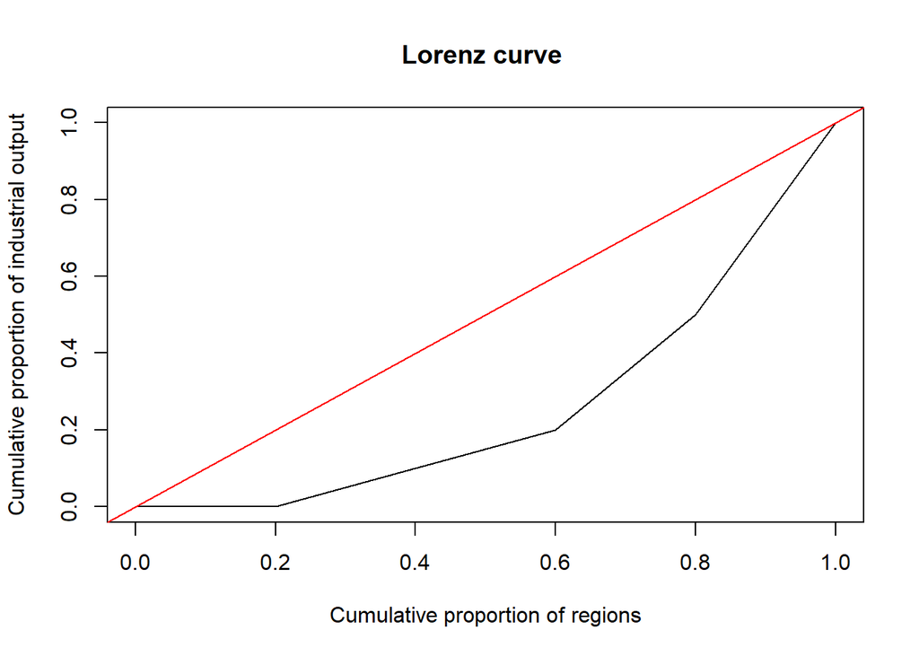

```r
Lorenz.curve (ind)
```

```r
Lorenz.curve (ind, pdf = TRUE)
```

```
## [1] "Lorenz.curve.pdf has been saved to your current working directory"
```

```r
Lorenz.curve (ind, plot = FALSE)
```

```
## $cum.reg
## [1] 0.0 0.2 0.4 0.6 0.8 1.0
##
## $cum.out
## [1] 0.0 0.0 0.1 0.2 0.5 1.0
```

GENERATE A REGION- INDUSTRY MATRIX

```r
mat= matrix (
  c (0, 1, 0, 0,
     0, 1, 0, 0,
     0, 1, 0, 0,
     0, 1, 0, 1,
     0, 1, 1, 1), ncol = 4, byrow = T)
rownames(mat) <- c ("R1", "R2", "R3", "R4", "R5")
colnames(mat) <- c ("I1", "I2", "I3", "I4")
```

RUN THE FUNCTION

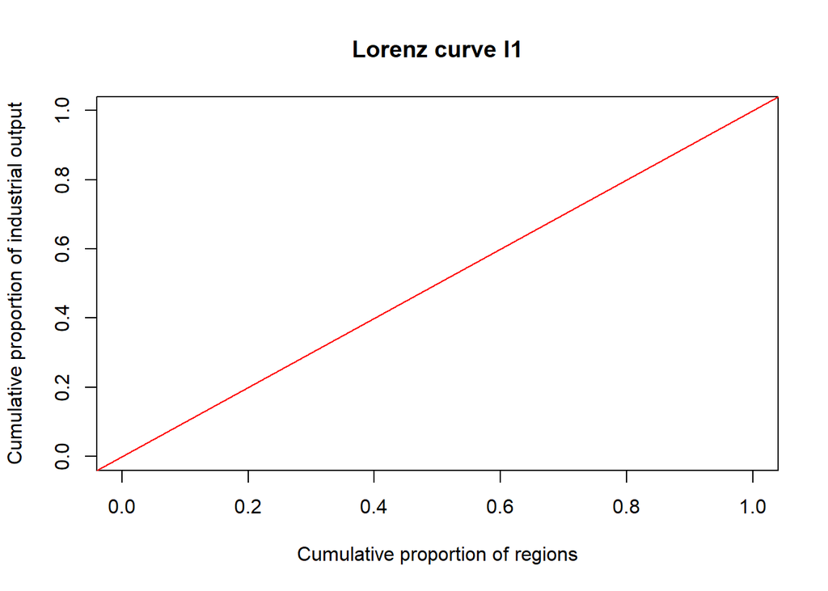

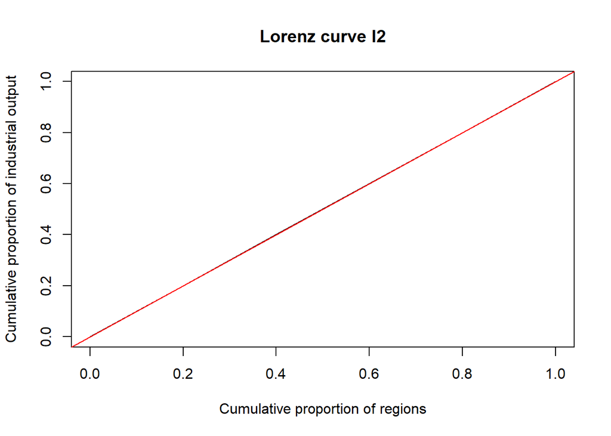

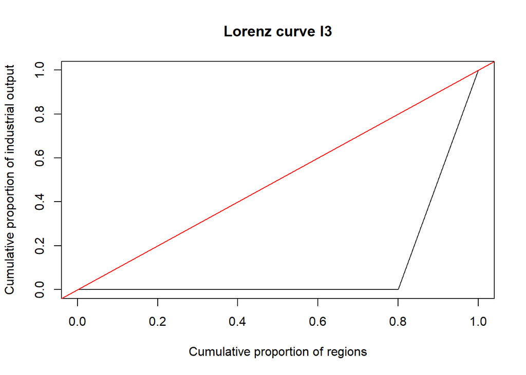

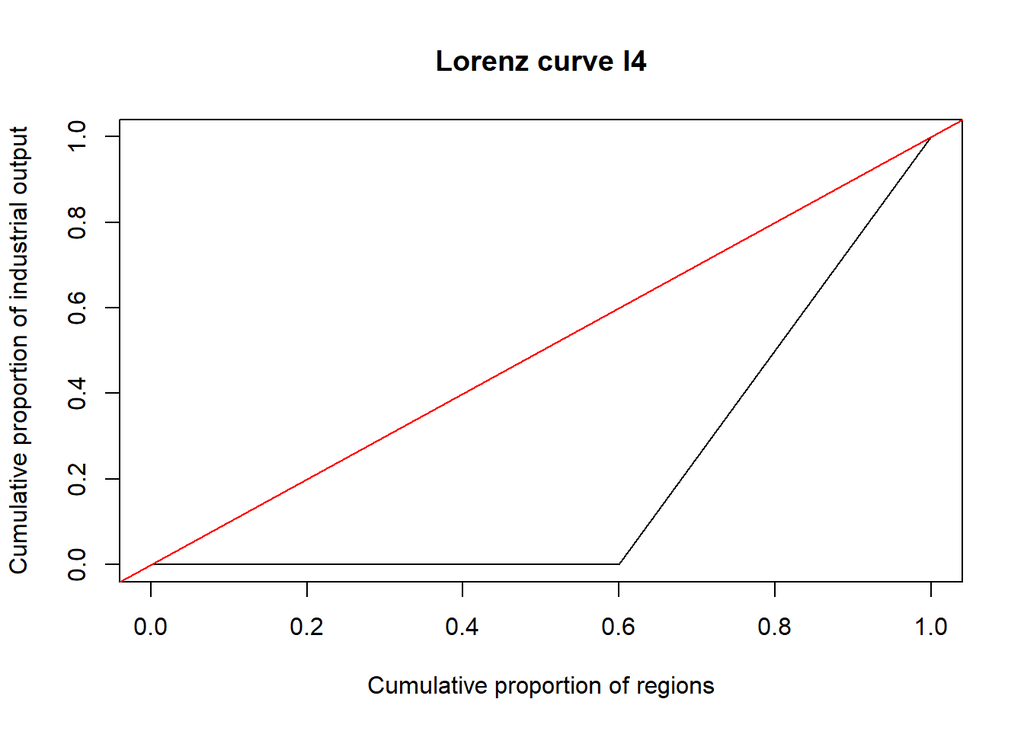

```r
Lorenz.curve (mat)
```

```r
Lorenz.curve (mat, pdf = TRUE)
```

```
## [1] "Lorenz.curve.pdf has been saved to your current working directory"
```

```r
Lorenz.curve (mat, plot = FALSE)
```

```
## $cum.reg
## [1] 0.0 0.2 0.4 0.6 0.8 1.0
##
## $cum.out
##      R1  R2  R3  R4  R5
##   0 NaN NaN NaN NaN NaN
```

RUN THE FUNCTION BY AGGREGATION ALL INDUSTRIES

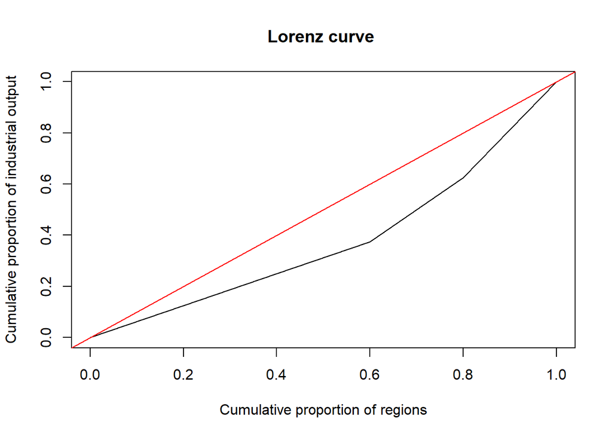

```r
Lorenz.curve (rowSums(mat))
```

```r
Lorenz.curve (rowSums(mat), pdf = TRUE)
```

```
## [1] "Lorenz.curve.pdf has been saved to your current working directory"
```

```r
Lorenz.curve (rowSums(mat), plot = FALSE)
```

```
## $cum.reg
## [1] 0.0 0.2 0.4 0.6 0.8 1.0
##
## $cum.out
##          R1    R2    R3    R4    R5
## 0.000 0.125 0.250 0.375 0.625 1.000
```

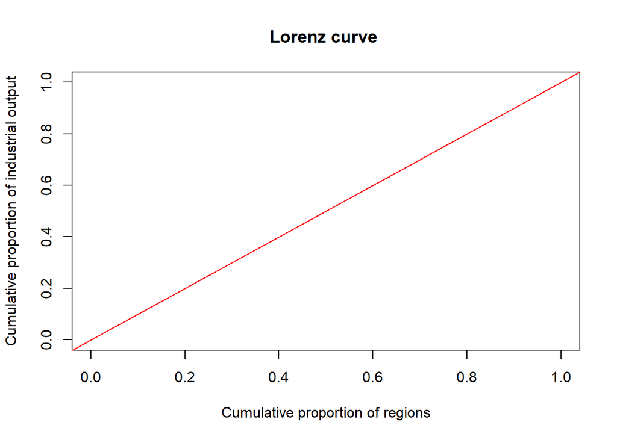

```r
Lorenz.curve (mat[,1])
```

```r
Lorenz.curve (mat[,1], pdf = TRUE)
```

```
## [1] "Lorenz.curve.pdf has been saved to your current working directory"
```

```r
Lorenz.curve (mat[,1], plot = FALSE)
```

```
## $cum.reg
## [1] 0.0 0.2 0.4 0.6 0.8 1.0
##
## $cum.out
##      R1  R2  R3  R4  R5
##   0 NaN NaN NaN NaN NaN
```

RUN THE FUNCTION FOR INDUSTRIY #2 ONLY (PERFECT EQUALITY)

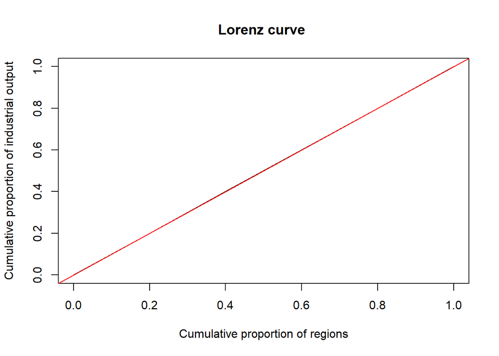

```r
Lorenz.curve (mat[,2])
```

```r
Lorenz.curve (mat[,2], pdf = TRUE)
```

```
## [1] "Lorenz.curve.pdf has been saved to your current working directory"
```

```r
Lorenz.curve (mat[,2], plot = FALSE)
```

```
## $cum.reg
## [1] 0.0 0.2 0.4 0.6 0.8 1.0
##
## $cum.out
##      R1  R2  R3  R4  R5
## 0.0 0.2 0.4 0.6 0.8 1.0
```

RUN THE FUNCTION FOR INDUSTRIY #3 ONLY (PERFECT UNEQUALITY)

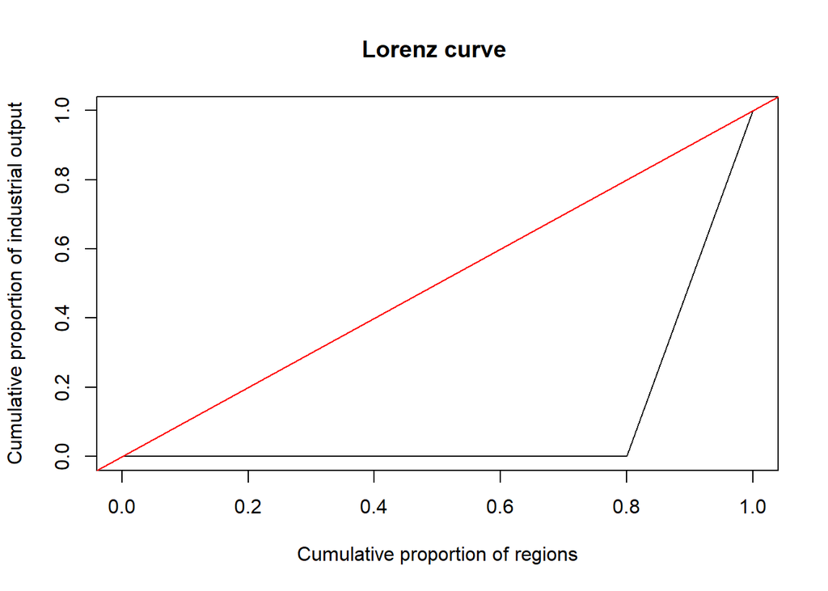

```r
Lorenz.curve (mat[,3])
```

```r
Lorenz.curve (mat[,3], pdf = TRUE)
```

```
## [1] "Lorenz.curve.pdf has been saved to your current working directory"
```

```r
Lorenz.curve (mat[,3], plot = FALSE)
```

```
## $cum.reg
## [1] 0.0 0.2 0.4 0.6 0.8 1.0
##
## $cum.out
##    R1 R2 R3 R4 R5
##  0  0  0  0  0  1
```

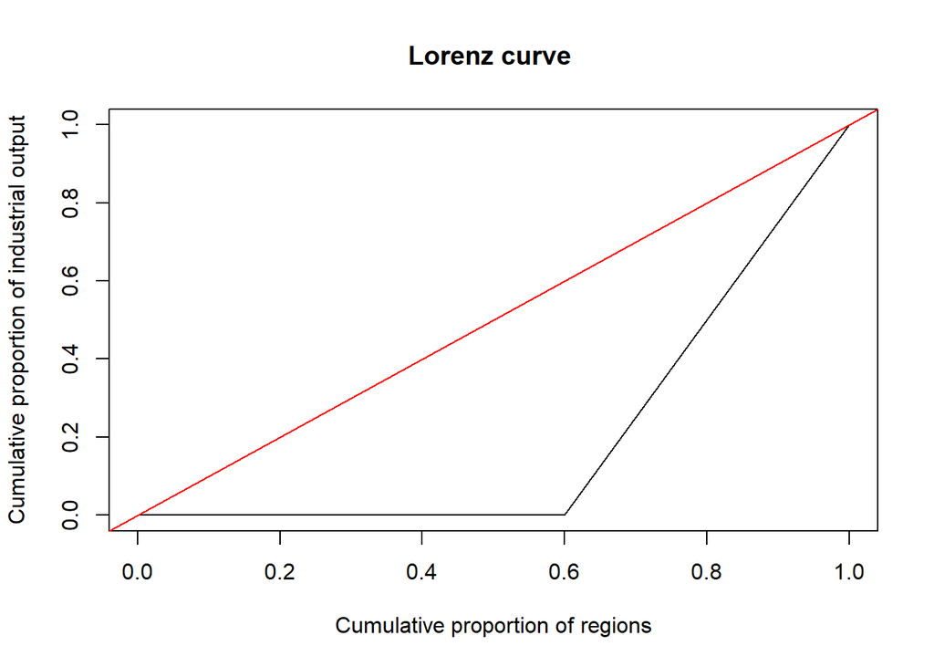

```r
Lorenz.curve (mat[,4])
```

```r
Lorenz.curve (mat[,4], pdf = TRUE)
```

```
## [1] "Lorenz.curve.pdf has been saved to your current working directory"
```

```r
Lorenz.curve (mat[,4], plot = FALSE)
```

```
## $cum.reg
## [1] 0.0 0.2 0.4 0.6 0.8 1.0
##
## $cum.out
##      R1  R2  R3  R4  R5
## 0.0 0.0 0.0 0.0 0.5 1.0
```

COMPARE THE DISTRIBUTION OF THE INDUSTRIES

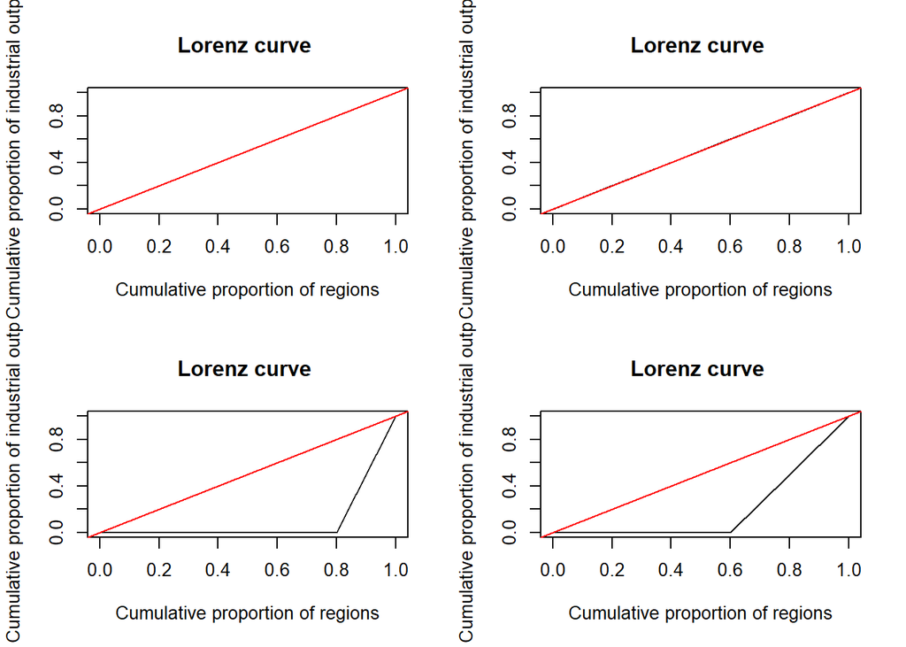

```r
par(mfrow=c(2,2))
Lorenz.curve (mat[,1])
Lorenz.curve (mat[,2])
Lorenz.curve (mat[,3])
Lorenz.curve (mat[,4])
```